# Análisis - Bebés recién nacidos

Frank Casanova

27/1/2022

# Análisis estadístico descriptivo sobre bebés recién nacidos

En ésta oportunidad de analizará la tabla `birthwt` ubicada dentro de el paquete `MASS` en `R`, que contiene datos que represemtam factores que pueden incidir en e peso de los niños al nacer.

## Instalación de `MASS` y carga de datos

A continuación se muestra la carga de los datos, es importante destacar que si el paquete no se encuentra instalado en tu ambiente de trabalo, lo puedes instalar con el siguiente commando `install.packages("MASS")` y activar la librería con `library("MASS")`.

```r
library("MASS")
datos=birthwt
```

Descripción general de los datos

```r
str(datos)
```

```
## 'data.frame':    189 obs. of  10 variables:
##  $ low  : int  0 0 0 0 0 0 0 0 0 0 ...
##  $ age  : int  19 33 20 21 18 21 22 17 29 26 ...
##  $ lwt  : int  182 155 105 108 107 124 118 103 123 113 ...
##  $ race : int  2 3 1 1 1 3 1 3 1 1 ...
##  $ smoke: int  0 0 1 1 1 0 0 0 1 1 ...
##  $ ptl  : int  0 0 0 0 0 0 0 0 0 0 ...
##  $ ht   : int  0 0 0 0 0 0 0 0 0 0 ...
##  $ ui   : int  1 0 0 1 1 0 0 0 0 0 ...
##  $ ftv  : int  0 3 1 2 0 0 1 1 1 0 ...
##  $ bwt  : int  2523 2551 2557 2594 2600 2622 2637 2637 2663 2665 ...
```

```r
head(datos, 5)
```

```
##    low age lwt race smoke ptl ht ui ftv  bwt
## 85   0  19 182    2     0   0  0  1   0 2523
## 86   0  33 155    3     0   0  0  0   3 2551
## 87   0  20 105    1     1   0  0  0   1 2557
## 88   0  21 108    1     1   0  0  1   2 2594
## 89   0  18 107    1     1   0  0  1   0 2600
```

## Influencia del raza de la madre en el peso del bebé

```r
peso_raza=table(datos[c("race","low")])
dimnames(peso_raza)=list(
  raza = c("Blanca", "Negra", "Otra"),
  peso = c("Mas de 2.5 kg", "Menos de 2.5 kg")
)
peso_raza # Frecuencias aboslutas
```

```
##         peso
## raza     Mas de 2.5 kg Menos de 2.5 kg
##   Blanca            73              23
##   Negra             15              11
##   Otra              42              25
```

```r
round(prop.table(peso_raza), 3)  # Frec. relativas globales
```

```
##         peso
## raza     Mas de 2.5 kg Menos de 2.5 kg
##   Blanca         0.386           0.122
##   Negra          0.079           0.058
##   Otra           0.222           0.132
```

```r
round(prop.table(peso_raza, margin = 1), 3) # Frec. relativas según raza
```

```
##         peso
## raza     Mas de 2.5 kg Menos de 2.5 kg
##   Blanca         0.760           0.240
##   Negra          0.577           0.423
##   Otra           0.627           0.373
```

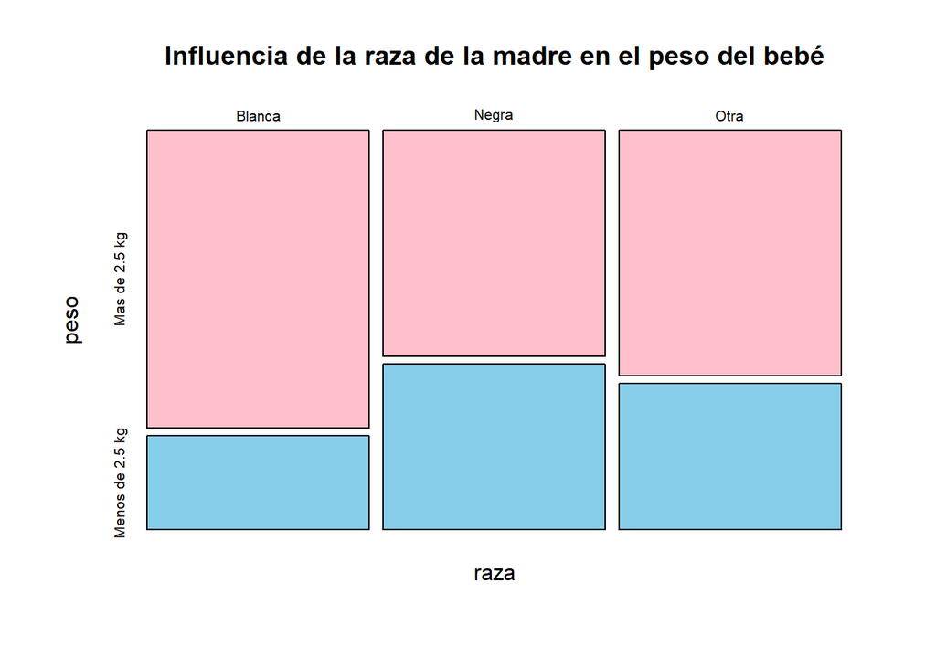

```r
mosaicplot((prop.table(peso_raza, margin = 1)),
           main="Influencia de la raza de la madre en el peso del bebé",
           col=c("pink", "skyblue"))
```

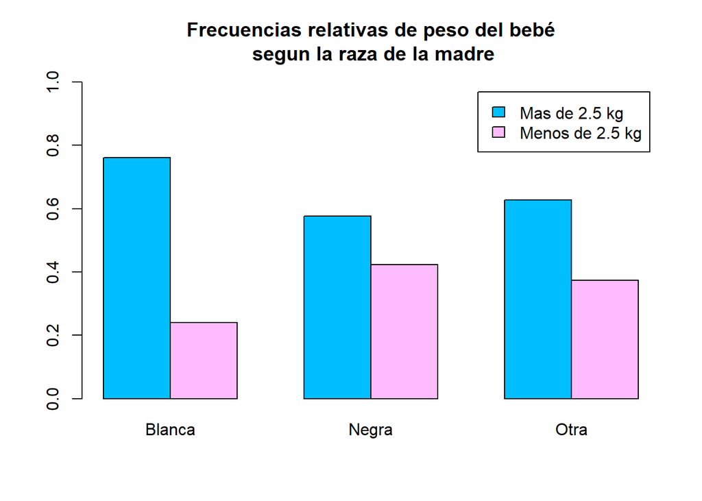

```r
barplot(t(prop.table(peso_raza, margin = 1)),
        main = "Frecuencias relativas de peso del bebé\n segun la raza de la madre",
        col=c("deepskyblue", "plum1"),
        legend.text = T,
        beside = T,
        ylim=c(0, 1))
```

## Influencia de si fuma o no fuma la madre en el peso del bebé

```r
peso_fuma = table(datos[c("low", "smoke")])
dimnames(peso_fuma)=list(
  peso = c("Más de 2.5 kg", "Menos de 2.5 kg"),
  fuma = c("No fuma", "Si fuma")
)

peso_fuma # Frecuencias absolutas
```

```
##                  fuma
## peso              No fuma Si fuma
##   Más de 2.5 kg        86      44
##   Menos de 2.5 kg      29      30
```

```r
prop.table(peso_fuma) # Frec. relativas globales
```

```
##                  fuma
## peso                No fuma   Si fuma
##   Más de 2.5 kg   0.4550265 0.2328042
##   Menos de 2.5 kg 0.1534392 0.1587302
```

```r
prop.table(peso_fuma, margin = 2) # Frec. relativas según si fuma o no fuma
```

```
##                  fuma
## peso                No fuma   Si fuma
##   Más de 2.5 kg   0.7478261 0.5945946
##   Menos de 2.5 kg 0.2521739 0.4054054
```

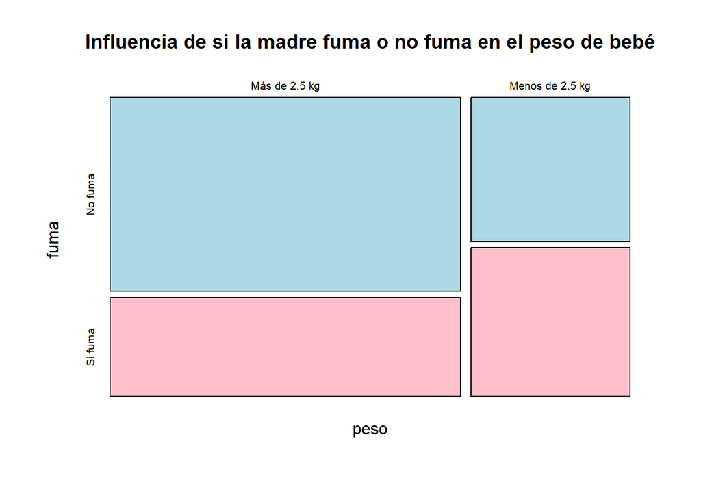

```r
mosaicplot(peso_fuma,
           main = "Influencia de si la madre fuma o no fuma en el peso de bebé",
           col = c("lightblue", "pink"))
```

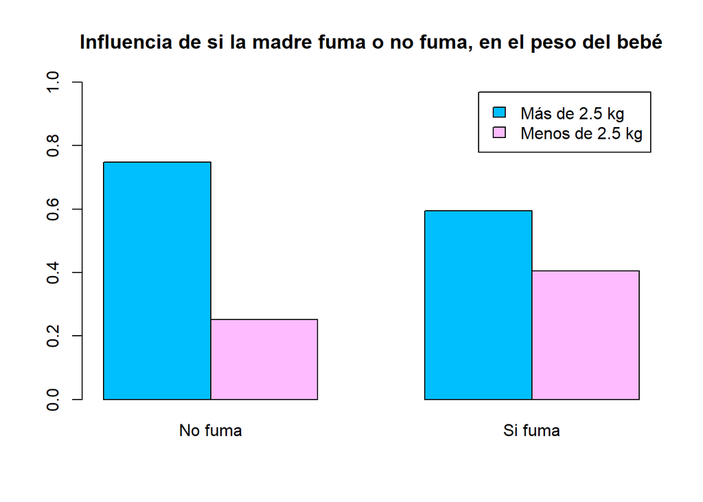

```r
barplot(prop.table(peso_fuma, margin = 2),
        main = "Influencia de si la madre fuma o no fuma, en el peso del bebé",
        col = c("deepskyblue", "plum1"),
        legend.text = T,
        beside = T,
        ylim = c(0,1))
```

Cuando la madre fuma durante el embaraso, aumenta las probabilidades de que el bebé recién nacido pese menos de 2.5 kg, por otro lado si la madre no fuma durantre el embaraso, aumentan las probabilidades de que su bebé recién nacido pese más de 2.5 kg.

## Influencia de si la madres es hipertensa o no, en el peso del bebé

```r
peso_hipert=table(datos[c("ht", "low")])
dimnames(peso_hipert)=list(
  hipertension = c("No", "Si"),
  peso = c("Más de 2.5 kg", "Menos de 2.5 kg")
)
peso_hipert # Frecuencias aboslutas
```

```
##             peso
## hipertension Más de 2.5 kg Menos de 2.5 kg
##           No           125              52
##           Si             5               7
```

```r
round(prop.table(peso_hipert), 3)  # Frec. relativas globales
```

```
##             peso
## hipertension Más de 2.5 kg Menos de 2.5 kg
##           No         0.661           0.275
##           Si         0.026           0.037
```

```r
round(prop.table(peso_hipert, margin = 1), 3) # Frec. relativas según si es hipertensa o no
```

```
##             peso
## hipertension Más de 2.5 kg Menos de 2.5 kg
##           No         0.706           0.294
##           Si         0.417           0.583
```

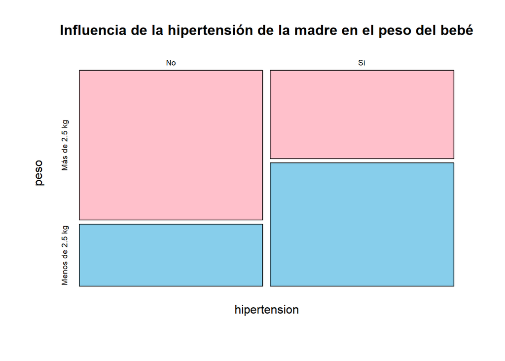

```r
mosaicplot((prop.table(peso_hipert, margin = 1)),
           main="Influencia de la hipertensión de la madre en el peso del bebé",
           col=c("pink", "skyblue"))
```

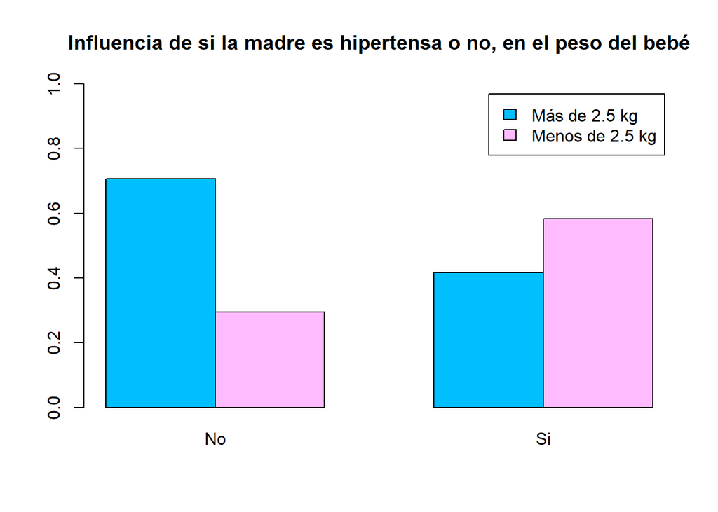

```r
barplot(t(prop.table(peso_hipert, margin = 1)),
        main = "Influencia de si la madre es hipertensa o no, en el peso del bebé",
        col = c("deepskyblue", "plum1"),
        legend.text = T,
        beside = T,
        ylim = c(0,1))
```

Como se puede notar en las gráficas, cuando la madre no tiene precedentes de hipertensión, el bebé recién nacido tiene más posibilidades de pesar más de 2.5 kg, por el contrario si la madre si presentó precedentes de hipertensión, el bebé tienes mas posibilidades de pesar menos de 2.5 kg.

## Influencia de la raza de la madre, condicion de madre fumadora o no sobre el peso del bebé

```r
peso_raza_fuma = table(datos[c("race", "low", "smoke")])
dimnames(peso_raza_fuma)=list(
  raza = c("Blanca", "Negra", "Otra"),
  peso = c("Mas de 2.5 kg", "Menos de 2.5 kg"),
  fuma = c("No fuma", "Si fuma")
)
round(prop.table(peso_raza_fuma),3) # Freccuencias realativas globales
```

```
## , , fuma = No fuma
##
##         peso
## raza     Mas de 2.5 kg Menos de 2.5 kg
##   Blanca         0.212           0.021
##   Negra          0.058           0.026
##   Otra           0.185           0.106
##
## , , fuma = Si fuma
##
##         peso
## raza     Mas de 2.5 kg Menos de 2.5 kg
##   Blanca         0.175           0.101
##   Negra          0.021           0.032
##   Otra           0.037           0.026
```

```r
round(prop.table(peso_raza_fuma, margin = c(1,3)),3) # Frec. relativas segun raza y condición fumadora
```

```
## , , fuma = No fuma
##
##         peso
## raza     Mas de 2.5 kg Menos de 2.5 kg
##   Blanca         0.909           0.091
##   Negra          0.688           0.312
##   Otra           0.636           0.364
##
## , , fuma = Si fuma
##
##         peso
## raza     Mas de 2.5 kg Menos de 2.5 kg
##   Blanca         0.635           0.365
##   Negra          0.400           0.600
##   Otra           0.583           0.417
```

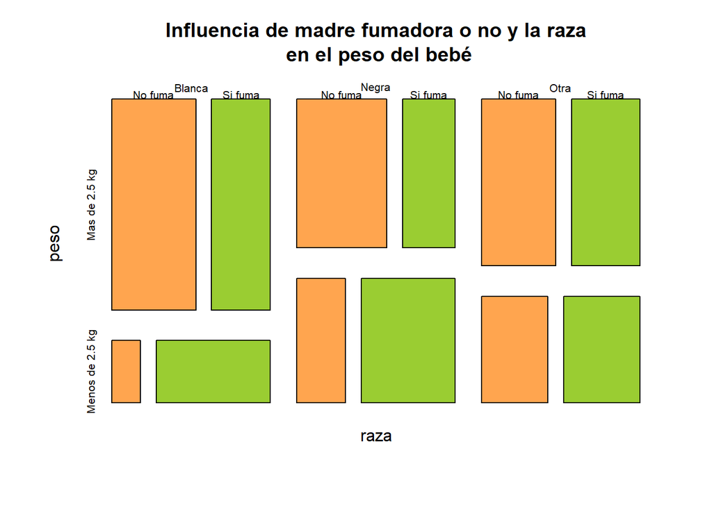

```r
mosaicplot(prop.table(peso_raza_fuma, margin = c(1,3)),
          col=c("tan1", "yellowgreen"),
          main="Influencia de madre fumadora o no y la raza\n en el peso del bebé")
```

También cabe destacar que hay más bebés que pesan más de 2.5 kg de madres de raza blanca que bebés que pesan menos de 2.5 kg de madres de raza negra.

Con respecto a los datos de madres de otras razas, muestra a un sector mas promedio con respecto a la cantiad de bebés con pesos mayores o menores a 2.5 kg y la tendencia con respecto a menor peso del bebé y madre fumadora se mantiene.